# Data Visualization with `ggplot2`

Ozancan Ozdemir

## **Data Visualization**

Data visualization is an essential tool in the realm of information analysis and presentation. It involves the graphical representation of data and statistics to uncover meaningful insights and communicate complex ideas in a clear and concise manner. As the volume and complexity of data continue to grow exponentially, data visualization plays a crucial role in transforming raw numbers into visual narratives that are easily digestible and comprehensible. By leveraging charts, graphs, maps, and interactive visual elements, data visualization allows individuals and organizations to explore patterns, identify trends, detect anomalies, and make data-driven decisions. Its importance lies in its ability to facilitate understanding, reveal patterns and correlations, highlight outliers, and support storytelling, enabling stakeholders to derive actionable insights from vast amounts of information.

Data visualization has a rich history that dates back centuries, evolving alongside humanity’s quest for understanding and representing information visually. Early examples of data visualization can be traced back to ancient civilizations, where visual symbols and hieroglyphics were used to convey important information and record historical events. In the 18th and 19th centuries, pioneers like William Playfair and Florence Nightingale revolutionized the field by introducing graphical methods to illustrate statistical data. Playfair’s invention of line, bar, and pie charts provided a visual framework for comparing quantities, while Nightingale’s famous coxcomb diagram effectively communicated the impact of preventable diseases on soldiers during the Crimean War. The advent of computer technology in the 20th century brought about a new era of data visualization, with advancements in software and hardware enabling the creation of interactive and dynamic visual representations. Today, with the explosion of big data and the need for data-driven decision-making, data visualization has become an indispensable tool in various domains, including business, science, journalism, and public policy. Its historical significance lies in its ability to transform complex data into intuitive visuals, empowering individuals and organizations to gain insights, communicate effectively, and make informed decisions in an increasingly data-driven world.

[figure not shown]

CoxBomb Diagram by Nightingale

## `ggplot2` **Package**

ggplot2, developed by H.Wickham, is a plotting system for R, based on the grammar of graphics, which tries to take the good parts of base and lattice graphics and none of the bad parts. It takes care of many of the fiddly details that make plotting a hassle (like drawing legends) as well as providing a powerful model of graphics that makes it easy to produce complex multi-layered graphics.

To get more information about this special packages, you can visit http://ggplot2.org/

Also, there are many videos, books and pages related to this packages. One of them is my book. :)

[An Introduction to ggplot2, Ozancan Ozdemir, 2022](https://bookdown.org/ozancanozdemir/introduction-to-ggplot2/)

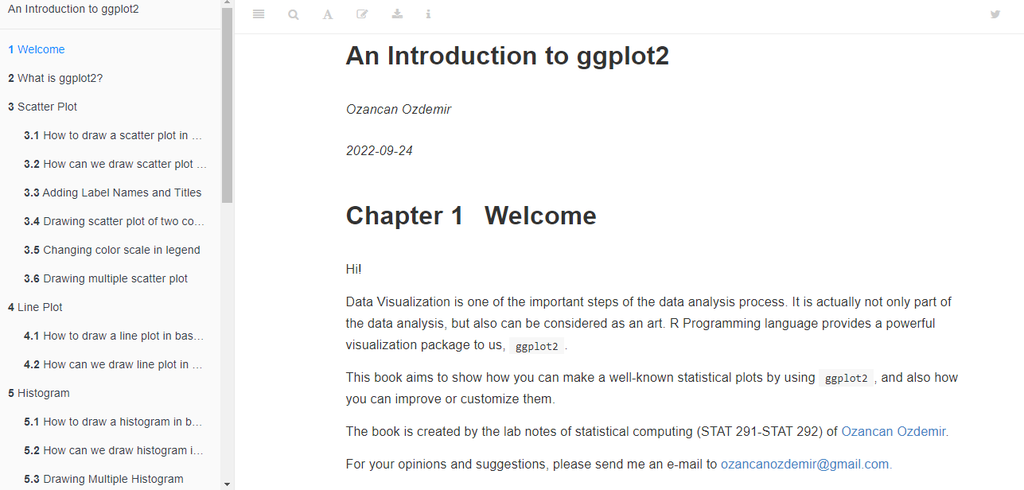

The ggplot2, shortly ggplot, implies “Grammar of Graphics” which believes in the principle that a plot can be split into the following basic parts -

*Plot = data + Aesthetics + Geometry*

- **data** refers to information you want to visualize.
- **Aesthetics** includes the specific variables that you use in drawing. i.e, x and y variables. It is also used to tell R how data are displayed in a plot, e.g. color, size and shape of points, transparency etc. All aesthetics for a plot are specified in the `aes()` function call
- **Geometry** refers to the type of graphics (bar chart, histogram, box plot, line plot, density plot, dot plot etc.) To see the list of geometric functions, please visit https://ggplot2.tidyverse.org/reference/

Here, you can see some functions from the list.

```
    geom_point() = Scatter Plot
    geom_bar() = Bar Plot
    geom_line() = Line Plot
    geom_histogram() = Histogram
    geom_boxplot() = Box Plot
    geom_density() = Density Plot
```

e.g

```
    library(ggplot2)
    ggplot(data,aes(x=x,y=y))+geom_point()
```

In addition to those functions, we use the following arguments or functions for our plots.

**Functions**

```
geom_text() = Add label or number on your plot

coord_flip() = Rotate your plot

theme() = Arrange the theme of your plot, e.g size of axis names etc.

facet_wrap() & facet_grid() = Plot for different subject of your data

scale_color_manual() = Change the color of your plot manually.

labs() = Set title, axis name etc.
```

**Arguments**

```
col = Change color of your plot by third variable (in aesthetics part)

group= Divide your data into third group (in aesthetics part)

color = Change frame of your box / bar or bin (in geom part)

fill = Fill your box / bar or bin (in geom part)
```

**Important Note**

`ggplot2` package works with **data.frame** and **tibble** objects.

**Why ggplot2 is better?**

- Excellent themes can be created with a single command.
- Its colors are nicer and more pretty than the usual graphics.
- Easy to visualize data with multiple variables.
- Provides a platform to create simple graphs providing plethora of information.

(Ozdemir, O, Lab Notes, 2019)

## **Case Study**

In this tutorial, we will use `diamond` dataset, which is built-in dataset in `ggplot2` to illustrate the plot types.

```r
library(ggplot2)
knitr::kable(head(diamonds))
```

| carat | cut | color | clarity | depth | table | price | x | y | z |
| --- | --- | --- | --- | --- | --- | --- | --- | --- | --- |
| 0.23 | Ideal | E | SI2 | 61.5 | 55 | 326 | 3.95 | 3.98 | 2.43 |
| 0.21 | Premium | E | SI1 | 59.8 | 61 | 326 | 3.89 | 3.84 | 2.31 |
| 0.23 | Good | E | VS1 | 56.9 | 65 | 327 | 4.05 | 4.07 | 2.31 |
| 0.29 | Premium | I | VS2 | 62.4 | 58 | 334 | 4.20 | 4.23 | 2.63 |
| 0.31 | Good | J | SI2 | 63.3 | 58 | 335 | 4.34 | 4.35 | 2.75 |
| 0.24 | Very Good | J | VVS2 | 62.8 | 57 | 336 | 3.94 | 3.96 | 2.48 |

Check the class of the variables in the data.

```r
dplyr::glimpse(diamonds)
```

```
## Rows: 53,940
## Columns: 10
## $ carat   <dbl> 0.23, 0.21, 0.23, 0.29, 0.31, 0.24, 0.24, 0.26, 0.22, 0.23, 0.~
## $ cut     <ord> Ideal, Premium, Good, Premium, Good, Very Good, Very Good, Ver~
## $ color   <ord> E, E, E, I, J, J, I, H, E, H, J, J, F, J, E, E, I, J, J, J, I,~
## $ clarity <ord> SI2, SI1, VS1, VS2, SI2, VVS2, VVS1, SI1, VS2, VS1, SI1, VS1, ~
## $ depth   <dbl> 61.5, 59.8, 56.9, 62.4, 63.3, 62.8, 62.3, 61.9, 65.1, 59.4, 64~
## $ table   <dbl> 55, 61, 65, 58, 58, 57, 57, 55, 61, 61, 55, 56, 61, 54, 62, 58~
## $ price   <int> 326, 326, 327, 334, 335, 336, 336, 337, 337, 338, 339, 340, 34~
## $ x       <dbl> 3.95, 3.89, 4.05, 4.20, 4.34, 3.94, 3.95, 4.07, 3.87, 4.00, 4.~
## $ y       <dbl> 3.98, 3.84, 4.07, 4.23, 4.35, 3.96, 3.98, 4.11, 3.78, 4.05, 4.~
## $ z       <dbl> 2.43, 2.31, 2.31, 2.63, 2.75, 2.48, 2.47, 2.53, 2.49, 2.39, 2.~
```

**Question: What is the frequency distribution of cut?**

**Bar Plot**

As seen above, `cut` is a categorical variable. The most appropriate and frequently used graphical tool for one categorical variable is **bar plot.**

There are two ways to create a bar plot in `ggplot2`.

The first one is to calculate a frequency table manually.

```r
t = table(diamonds$cut)
class(t)
```

```
## [1] "table"
```

```r
t
```

```
##
##      Fair      Good Very Good   Premium     Ideal
##      1610      4906     12082     13791     21551
```

Then, convert your table object into the data frame or tibble.

```r
df = data.frame(t)
df
```

```
##        Var1  Freq
## 1      Fair  1610
## 2      Good  4906
## 3 Very Good 12082
## 4   Premium 13791
## 5     Ideal 21551
```

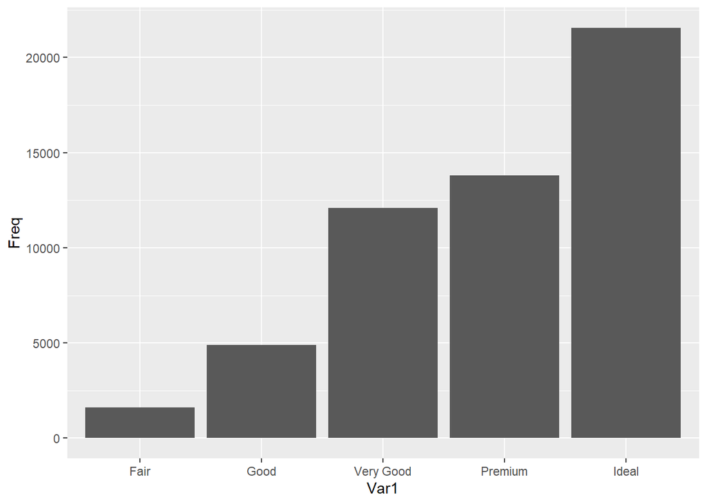

```r
library(ggplot2)
ggplot(df,aes(x=Var1,y=Freq))+geom_bar(stat="identity")
```

```r
#stat="identity" must argument
```

`labs()` function helps you adding title, axis names to your plot.

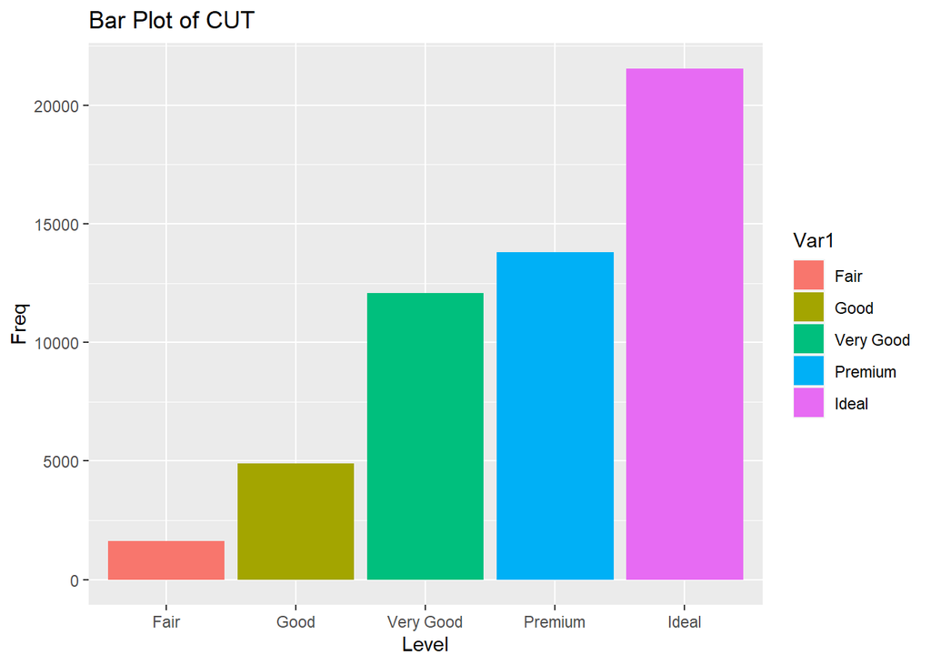

```r
ggplot(df,aes(x=Var1,y=Freq,fill=Var1))+geom_bar(stat="identity")+
  labs(title="Bar Plot of CUT",y="Freq",x="Level")
```

`geom_text()` helps you adding numbers or text to your plot. You can also use `annotate`. [See.](https://ggplot2.tidyverse.org/reference/annotate.html)

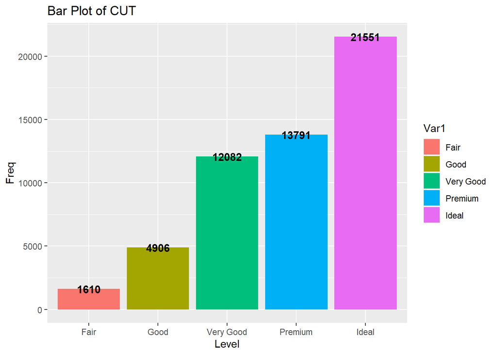

```r
ggplot(df,aes(x=Var1,y=Freq,fill=Var1))+geom_bar(stat="identity")+
  labs(title="Bar Plot of CUT",y="Freq",x="Level")+geom_text(aes(label=Freq),fontface="bold")
```

```r
#label a must argument
```

To adjust the position of texts, you can use the arguments `vjust` or `hjust`.

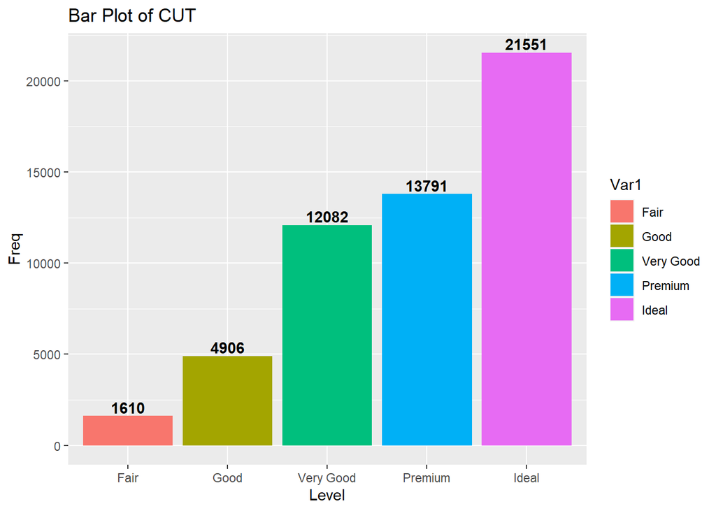

```r
ggplot(df,aes(x=Var1,y=Freq,fill=Var1))+geom_bar(stat="identity")+
  labs(title="Bar Plot of CUT",y="Freq",x="Level")+geom_text(aes(label=Freq),vjust=-0.25,fontface="bold")
```

```r
#label a must argument
```

In an ideal bar graph, values should be arranged in descending order, from largest to smallest.

**Ordering x axis**

Use `reorder()` argument for x axis.

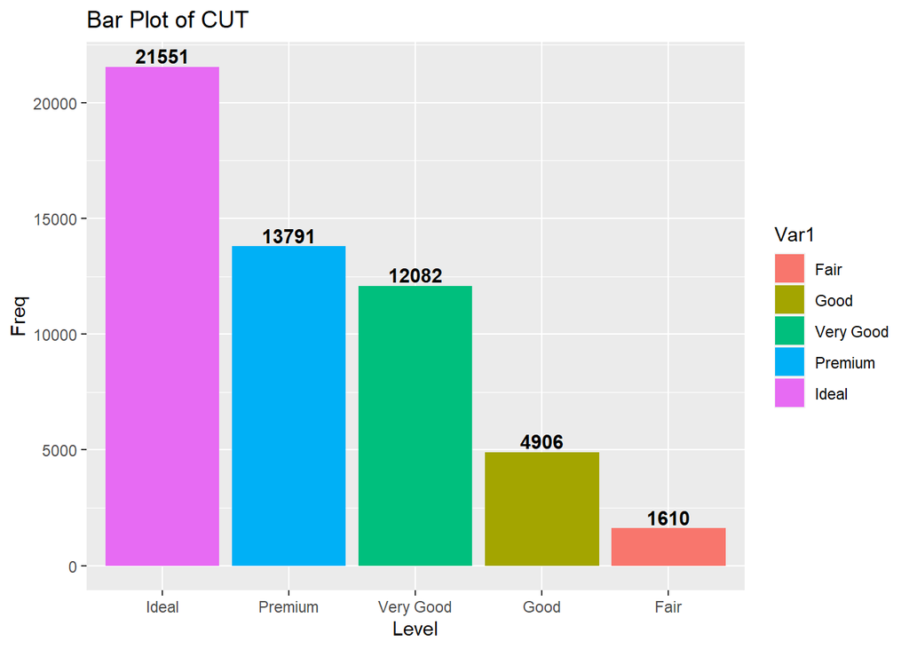

```r
ggplot(df,aes(x=reorder(Var1,-Freq),y=Freq,fill=Var1))+geom_bar(stat="identity")+
  labs(title="Bar Plot of CUT",y="Freq",x="Level")+geom_text(aes(label=Freq),vjust=-0.25,fontface="bold")
```

If you have a raw data to be visualized, you can use `stat = "count"` argument in place of `stat="identity`.

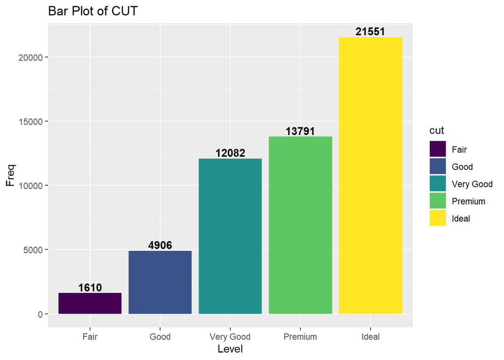

```r
ggplot(diamonds,aes(x=cut, fill = cut))+geom_bar()+
  labs(title="Bar Plot of CUT",y="Freq",x="Level")+geom_text(stat="count",aes(label =..count..),vjust=-0.25,fontface="bold")
```

**Question: What is the distribution of carat?**

**Histogram/Density Plot/Box Plot**